# Mental Health in Tech

```python
import pandas as pd
import seaborn as sns
# print all the outputs in a cell
from IPython.core.interactiveshell import InteractiveShell
InteractiveShell.ast_node_interactivity = "all"
import warnings
warnings.filterwarnings("ignore")
import pydotplus
from IPython.display import Image
import sklearn as sk
import sklearn.tree as tree
```

```python
import plotly
import plotly.plotly as py
from plotly.graph_objs import *
import plotly.graph_objs as go
#It is necessary to create a plotly ac
#count and get an api_key
#Please create your own account and don't use my account!
plotly.tools.set_credentials_file(username='shwetha.pindikuri', api_key='qOikXKBkUYClBkHPKPSh')
pd.set_option('display.max_columns', 100)
```

Loading the Mental Health in Tech dataset

Dataset Overview- This dataset is sample of 1433 people and 63 questions relating to mental health of people within the tech industry

```python
df = pd.read_csv("mental-heath-in-tech-2016_20161114.csv")
```

```python
df.head()
```

|  | Are you self-employed? | How many employees does your company or organization have? | Is your employer primarily a tech company/organization? | Is your primary role within your company related to tech/IT? | Does your employer provide mental health benefits as part of healthcare coverage? | Do you know the options for mental health care available under your employer-provided coverage? | Has your employer ever formally discussed mental health (for example, as part of a wellness campaign or other official communication)? | Does your employer offer resources to learn more about mental health concerns and options for seeking help? | Is your anonymity protected if you choose to take advantage of mental health or substance abuse treatment resources provided by your employer? | If a mental health issue prompted you to request a medical leave from work, asking for that leave would be: | Do you think that discussing a mental health disorder with your employer would have negative consequences? | Do you think that discussing a physical health issue with your employer would have negative consequences? | Would you feel comfortable discussing a mental health disorder with your coworkers? | Would you feel comfortable discussing a mental health disorder with your direct supervisor(s)? | Do you feel that your employer takes mental health as seriously as physical health? | Have you heard of or observed negative consequences for co-workers who have been open about mental health issues in your workplace? | Do you have medical coverage (private insurance or state-provided) which includes treatment of mental health issues? | Do you know local or online resources to seek help for a mental health disorder? | If you have been diagnosed or treated for a mental health disorder, do you ever reveal this to clients or business contacts? | If you have revealed a mental health issue to a client or business contact, do you believe this has impacted you negatively? | If you have been diagnosed or treated for a mental health disorder, do you ever reveal this to coworkers or employees? | If you have revealed a mental health issue to a coworker or employee, do you believe this has impacted you negatively? | Do you believe your productivity is ever affected by a mental health issue? | If yes, what percentage of your work time (time performing primary or secondary job functions) is affected by a mental health issue? | Do you have previous employers? | Have your previous employers provided mental health benefits? | Were you aware of the options for mental health care provided by your previous employers? | Did your previous employers ever formally discuss mental health (as part of a wellness campaign or other official communication)? | Did your previous employers provide resources to learn more about mental health issues and how to seek help? | … |
| --- | --- | --- | --- | --- | --- | --- | --- | --- | --- | --- | --- | --- | --- | --- | --- | --- | --- | --- | --- | --- | --- | --- | --- | --- | --- | --- | --- | --- | --- | --- |
| 0 | 0 | 26-100 | 1.0 | NaN | Not eligible for coverage / N/A | NaN | No | No | I don't know | Very easy | No | No | Maybe | Yes | I don't know | No | NaN | NaN | NaN | NaN | NaN | NaN | NaN | NaN | 1 | No, none did | N/A (not currently aware) | I don't know | None did | … |
| 1 | 0 | 6-25 | 1.0 | NaN | No | Yes | Yes | Yes | Yes | Somewhat easy | No | No | Maybe | Yes | Yes | No | NaN | NaN | NaN | NaN | NaN | NaN | NaN | NaN | 1 | Yes, they all did | I was aware of some | None did | Some did | … |
| 2 | 0 | 6-25 | 1.0 | NaN | No | NaN | No | No | I don't know | Neither easy nor difficult | Maybe | No | Maybe | Maybe | I don't know | No | NaN | NaN | NaN | NaN | NaN | NaN | NaN | NaN | 1 | No, none did | N/A (not currently aware) | None did | Some did | … |
| 3 | 1 | NaN | NaN | NaN | NaN | NaN | NaN | NaN | NaN | NaN | NaN | NaN | NaN | NaN | NaN | NaN | 1.0 | Yes, I know several | Sometimes, if it comes up | I'm not sure | Sometimes, if it comes up | I'm not sure | Yes | 1-25% | 1 | Some did | N/A (not currently aware) | None did | None did | … |
| 4 | 0 | 6-25 | 0.0 | 1.0 | Yes | Yes | No | No | No | Neither easy nor difficult | Yes | Maybe | Maybe | No | No | No | NaN | NaN | NaN | NaN | NaN | NaN | NaN | NaN | 1 | I don't know | N/A (not currently aware) | Some did | None did | … |

## Dataset overview

```python
df.head()
```

|  | Are you self-employed? | How many employees does your company or organization have? | Is your employer primarily a tech company/organization? | Is your primary role within your company related to tech/IT? | Does your employer provide mental health benefits as part of healthcare coverage? | Do you know the options for mental health care available under your employer-provided coverage? | Has your employer ever formally discussed mental health (for example, as part of a wellness campaign or other official communication)? | Does your employer offer resources to learn more about mental health concerns and options for seeking help? | Is your anonymity protected if you choose to take advantage of mental health or substance abuse treatment resources provided by your employer? | If a mental health issue prompted you to request a medical leave from work, asking for that leave would be: | Do you think that discussing a mental health disorder with your employer would have negative consequences? | Do you think that discussing a physical health issue with your employer would have negative consequences? | Would you feel comfortable discussing a mental health disorder with your coworkers? | Would you feel comfortable discussing a mental health disorder with your direct supervisor(s)? | Do you feel that your employer takes mental health as seriously as physical health? | Have you heard of or observed negative consequences for co-workers who have been open about mental health issues in your workplace? | Do you have medical coverage (private insurance or state-provided) which includes treatment of mental health issues? | Do you know local or online resources to seek help for a mental health disorder? | If you have been diagnosed or treated for a mental health disorder, do you ever reveal this to clients or business contacts? | If you have revealed a mental health issue to a client or business contact, do you believe this has impacted you negatively? | If you have been diagnosed or treated for a mental health disorder, do you ever reveal this to coworkers or employees? | If you have revealed a mental health issue to a coworker or employee, do you believe this has impacted you negatively? | Do you believe your productivity is ever affected by a mental health issue? | If yes, what percentage of your work time (time performing primary or secondary job functions) is affected by a mental health issue? | Do you have previous employers? | Have your previous employers provided mental health benefits? | Were you aware of the options for mental health care provided by your previous employers? | Did your previous employers ever formally discuss mental health (as part of a wellness campaign or other official communication)? | Did your previous employers provide resources to learn more about mental health issues and how to seek help? | … |
| --- | --- | --- | --- | --- | --- | --- | --- | --- | --- | --- | --- | --- | --- | --- | --- | --- | --- | --- | --- | --- | --- | --- | --- | --- | --- | --- | --- | --- | --- | --- |
| 0 | 0 | 26-100 | 1.0 | NaN | Not eligible for coverage / N/A | NaN | No | No | I don't know | Very easy | No | No | Maybe | Yes | I don't know | No | NaN | NaN | NaN | NaN | NaN | NaN | NaN | NaN | 1 | No, none did | N/A (not currently aware) | I don't know | None did | … |
| 1 | 0 | 6-25 | 1.0 | NaN | No | Yes | Yes | Yes | Yes | Somewhat easy | No | No | Maybe | Yes | Yes | No | NaN | NaN | NaN | NaN | NaN | NaN | NaN | NaN | 1 | Yes, they all did | I was aware of some | None did | Some did | … |
| 2 | 0 | 6-25 | 1.0 | NaN | No | NaN | No | No | I don't know | Neither easy nor difficult | Maybe | No | Maybe | Maybe | I don't know | No | NaN | NaN | NaN | NaN | NaN | NaN | NaN | NaN | 1 | No, none did | N/A (not currently aware) | None did | Some did | … |
| 3 | 1 | NaN | NaN | NaN | NaN | NaN | NaN | NaN | NaN | NaN | NaN | NaN | NaN | NaN | NaN | NaN | 1.0 | Yes, I know several | Sometimes, if it comes up | I'm not sure | Sometimes, if it comes up | I'm not sure | Yes | 1-25% | 1 | Some did | N/A (not currently aware) | None did | None did | … |
| 4 | 0 | 6-25 | 0.0 | 1.0 | Yes | Yes | No | No | No | Neither easy nor difficult | Yes | Maybe | Maybe | No | No | No | NaN | NaN | NaN | NaN | NaN | NaN | NaN | NaN | 1 | I don't know | N/A (not currently aware) | Some did | None did | … |

## Data Cleaning and Preparation

Changing column names

```python
df.columns=['Self-Employed',
'CompanySize',
'Tech/Organization',
'RoleInTech',
'Coverage_mentalhealth',
'AwarenessofMentalCare',
'DiscussMentalHealth',
'Resoursesoffered',
'AnonimityProtected',
'MedicalLeave',
'NegConsequDiscussion',
'Phnegative',
'MHw_coworkers',
'MHw_supervisors',
'superviorweighMH_PH_equally',
'NegConsecoworkerdiscussMH',
'MedicalcoverMHincluded',
'online/localresourse',
'RevealMH_clients',
'RevealMH_clients_neg',
'RevealMHco-workers',
'RevealMHco-workers_neg',
'ProductivityAffectedMH',
'Worktime%_affby_MH',
'Previousemployers',
'EXEmpMHCoverage',
'MHCoverageExEmp',
'ExEmpDiscussMentalHealth',
'ExEmpEducateMH',
'ExEmpAnonimityProtected',
'ExEmpNegConsediscussMH',
'ExEmpNegConsediscussPH',
'DiscussMHwithPreviousEmployee',
'DiscussMHwithPreviousSupervisor',
'ExEmpweighMH_PH_equally',
'ExEmpNegConsecoworkerdiscussMH',
'PH_in_PEInterview',
'PH_in_PEInterviewDesc',
'MI_in_PEInterview',
'Mi_in_InterviewDesc',
'MH_HurtCareer',
'Co-workerViewNegatively',
'ShareMHtoRelatives',
'Unsupportive/BadResponseMH',
'IndividualResponibletounreveal',
'MIFamily',
'Past_MHDisorder',
'Current_MHDisorder',
'Ydiagnosis',
'MayBeDiagnosis',
'MHDiagnosed',
'MHDiagnosedDesc',
'MH_Seek_Treatment',
'MH_InterfereswithworkTreatedEffectively',
'MH_InterfereswithworkNottreatedEffectively',
'Age',
'Gender',
'Country_Living',
'USState_Living',
'Country_Working',
'USState_Working',
'WorkPosition',
'WorkRemotely']
```

```python
df.head()
```

|  | Self-Employed | CompanySize | Tech/Organization | RoleInTech | Coverage_mentalhealth | AwarenessofMentalCare | DiscussMentalHealth | Resoursesoffered | AnonimityProtected | MedicalLeave | NegConsequDiscussion | Phnegative | MHw_coworkers | MHw_supervisors | superviorweighMH_PH_equally | NegConsecoworkerdiscussMH | MedicalcoverMHincluded | online/localresourse | RevealMH_clients | RevealMH_clients_neg | RevealMHco-workers | RevealMHco-workers_neg | ProductivityAffectedMH | Worktime%_affby_MH | Previousemployers | EXEmpMHCoverage | MHCoverageExEmp | ExEmpDiscussMentalHealth | ExEmpEducateMH | … |
| --- | --- | --- | --- | --- | --- | --- | --- | --- | --- | --- | --- | --- | --- | --- | --- | --- | --- | --- | --- | --- | --- | --- | --- | --- | --- | --- | --- | --- | --- | --- |
| 0 | 0 | 26-100 | 1.0 | NaN | Not eligible for coverage / N/A | NaN | No | No | I don't know | Very easy | No | No | Maybe | Yes | I don't know | No | NaN | NaN | NaN | NaN | NaN | NaN | NaN | NaN | 1 | No, none did | N/A (not currently aware) | I don't know | None did | … |
| 1 | 0 | 6-25 | 1.0 | NaN | No | Yes | Yes | Yes | Yes | Somewhat easy | No | No | Maybe | Yes | Yes | No | NaN | NaN | NaN | NaN | NaN | NaN | NaN | NaN | 1 | Yes, they all did | I was aware of some | None did | Some did | … |
| 2 | 0 | 6-25 | 1.0 | NaN | No | NaN | No | No | I don't know | Neither easy nor difficult | Maybe | No | Maybe | Maybe | I don't know | No | NaN | NaN | NaN | NaN | NaN | NaN | NaN | NaN | 1 | No, none did | N/A (not currently aware) | None did | Some did | … |
| 3 | 1 | NaN | NaN | NaN | NaN | NaN | NaN | NaN | NaN | NaN | NaN | NaN | NaN | NaN | NaN | NaN | 1.0 | Yes, I know several | Sometimes, if it comes up | I'm not sure | Sometimes, if it comes up | I'm not sure | Yes | 1-25% | 1 | Some did | N/A (not currently aware) | None did | None did | … |
| 4 | 0 | 6-25 | 0.0 | 1.0 | Yes | Yes | No | No | No | Neither easy nor difficult | Yes | Maybe | Maybe | No | No | No | NaN | NaN | NaN | NaN | NaN | NaN | NaN | NaN | 1 | I don't know | N/A (not currently aware) | Some did | None did | … |

Total number of surveys-

```python
len(df)
```

```
1433
```

```python
df2 = df.copy()
```

Each column and the total number of NaN values

```python
df2.isna().sum()
```

```
Self-Employed                                    0
CompanySize                                    287
Tech/Organization                              287
RoleInTech                                    1170
Coverage_mentalhealth                          287
AwarenessofMentalCare                          420
DiscussMentalHealth                            287
Resoursesoffered                               287
AnonimityProtected                             287
MedicalLeave                                   287
NegConsequDiscussion                           287
Phnegative                                     287
MHw_coworkers                                  287
MHw_supervisors                                287
superviorweighMH_PH_equally                    287
NegConsecoworkerdiscussMH                      287
MedicalcoverMHincluded                        1146
online/localresourse                          1146
RevealMH_clients                              1146
RevealMH_clients_neg                          1289
RevealMHco-workers                            1146
RevealMHco-workers_neg                        1146
ProductivityAffectedMH                        1146
Worktime%_affby_MH                            1229
Previousemployers                                0
EXEmpMHCoverage                                169
MHCoverageExEmp                                169
ExEmpDiscussMentalHealth                       169
ExEmpEducateMH                                 169
ExEmpAnonimityProtected                        169
                                              ...
DiscussMHwithPreviousSupervisor                169
ExEmpweighMH_PH_equally                        169
ExEmpNegConsecoworkerdiscussMH                 169
PH_in_PEInterview                                0
PH_in_PEInterviewDesc                          338
MI_in_PEInterview                                0
Mi_in_InterviewDesc                            307
MH_HurtCareer                                    0
Co-workerViewNegatively                          0
ShareMHtoRelatives                               0
Unsupportive/BadResponseMH                      89
IndividualResponibletounreveal                 776
MIFamily                                         0
Past_MHDisorder                                  0
Current_MHDisorder                               0
Ydiagnosis                                     865
MayBeDiagnosis                                1111
MHDiagnosed                                      0
MHDiagnosedDesc                                722
MH_Seek_Treatment                                0
MH_InterfereswithworkTreatedEffectively          0
MH_InterfereswithworkNottreatedEffectively       0
Age                                              0
Gender                                           3
Country_Living                                   0
USState_Living                                 593
Country_Working                                  0
USState_Working                                582
WorkPosition                                     0
WorkRemotely                                     0
Length: 63, dtype: int64
```

Dropped all the columns where NAN is more than 75%

```python
df.dropna(thresh=340, axis=1, inplace=True)
```

```python
df.isna().sum()
```

```
Self-Employed                                   0
CompanySize                                   287
Tech/Organization                             287
Coverage_mentalhealth                         287
AwarenessofMentalCare                         420
DiscussMentalHealth                           287
Resoursesoffered                              287
AnonimityProtected                            287
MedicalLeave                                  287
NegConsequDiscussion                          287
Phnegative                                    287
MHw_coworkers                                 287
MHw_supervisors                               287
superviorweighMH_PH_equally                   287
NegConsecoworkerdiscussMH                     287
Previousemployers                               0
EXEmpMHCoverage                               169
MHCoverageExEmp                               169
ExEmpDiscussMentalHealth                      169
ExEmpEducateMH                                169
ExEmpAnonimityProtected                       169
ExEmpNegConsediscussMH                        169
ExEmpNegConsediscussPH                        169
DiscussMHwithPreviousEmployee                 169
DiscussMHwithPreviousSupervisor               169
ExEmpweighMH_PH_equally                       169
ExEmpNegConsecoworkerdiscussMH                169
PH_in_PEInterview                               0
PH_in_PEInterviewDesc                         338
MI_in_PEInterview                               0
Mi_in_InterviewDesc                           307
MH_HurtCareer                                   0
Co-workerViewNegatively                         0
ShareMHtoRelatives                              0
Unsupportive/BadResponseMH                     89
IndividualResponibletounreveal                776
MIFamily                                        0
Past_MHDisorder                                 0
Current_MHDisorder                              0
Ydiagnosis                                    865
MHDiagnosed                                     0
MHDiagnosedDesc                               722
MH_Seek_Treatment                               0
MH_InterfereswithworkTreatedEffectively         0
MH_InterfereswithworkNottreatedEffectively      0
Age                                             0
Gender                                          3
Country_Living                                  0
USState_Living                                593
Country_Working                                 0
USState_Working                               582
WorkPosition                                    0
WorkRemotely                                    0
dtype: int64
```

```python
df.replace(to_replace='No',value=0.0,inplace=True)
df.replace(to_replace='Yes',value=1.0,inplace=True)
df.replace(to_replace='I don\'t know',value=0.0,inplace=True)
df.replace(to_replace=['Yes, they all did', 'Yes, at all of my previous employers'],value=1.0,inplace=True)
df.replace(to_replace='None did',value=0.0,inplace=True)
df.replace(to_replace=['Not eligible for coverage / N/A','N/A (not currently aware)','Not applicable to me (I do not have a mental i...','Not applicable to me (I do not have a mental illness)'],value=0.0, inplace= True)
df.replace(to_replace=['Yes, all of them','Yes, I was aware of all of them','Yes, I think they would'],value=1.0, inplace= True)
df.replace(to_replace=['None of them','No, none did', 'Not applicable to me'],value=0.0, inplace= True)
df.replace(to_replace='Maybe' ,value=0.5, inplace= True)
df.replace(to_replace=['Some did','I was aware of some','Some of my previous employers','Somewhat not open' ],value=0.5, inplace= True)
df.replace(to_replace='Some of them' ,value=0.5, inplace= True)
```

```python
df.replace(to_replace=['No, it has not', 'No, at none of my previous employers','No, I only became aware later', 'No, they do not'],value=0.0,inplace=True)
df.replace(to_replace='No, I don\'t think it would',value=0,inplace=True)
df.replace(to_replace='No, I don\'t think they would',value=0,inplace=True)
df.replace(to_replace='Yes, it has',value=1.0,inplace=True)
df.replace(to_replace='Very open',value=1.0,inplace=True)
df.replace(to_replace='Somewhat open',value=0.5,inplace=True)
df.replace(to_replace='Yes, I think it would',value=1,inplace=True)
df.replace(to_replace='Neutral',value=0.5,inplace=True)
df.replace(to_replace='Somewhat open',value=0.5,inplace=True)
df.replace(to_replace='Not open at all',value=0,inplace=True)
df.replace(to_replace='Maybe/Not sure',value=0.5,inplace=True)
df.replace(to_replace=['Yes, I experienced','Yes, I observed','Yes, they do'],value=1,inplace=True)
df.replace(to_replace='Often',value=1,inplace=True)
df.replace(to_replace=['Sometimes','Rarely'],value=0.5,inplace=True)
df.replace(to_replace='Never',value=0,inplace=True)
df.replace(to_replace='Always',value=1,inplace=True)
df.replace(to_replace='Always',value=1,inplace=True)
```

```python
df.replace(to_replace='I am not sure',value=0.5,inplace=True)
df.MedicalLeave.replace(to_replace=['Somewhat easy', 'Very easy'],value='Easy',inplace=True)
df.MedicalLeave.replace(to_replace=['Very difficult', 'Very difficult'],value='Difficult',inplace=True)
df.MedicalLeave.replace(to_replace=['Neither easy nor difficult'],value='Medium',inplace=True)
df.ExEmpAnonimityProtected.replace(to_replace='Yes, always', value=1.0, inplace= True)
```

Showing all the unique columns in the Gender column

```python
df.Gender.unique()
```

```
array(['Male', 'male', 'Male ', 'Female', 'M', 'female', 'm',
       'I identify as female.', 'female ', 'Bigender', 'non-binary',
       'Female assigned at birth ', 'F', 'Woman', 'man', 'fm', 'f',
       'Cis female ', 'Transitioned, M2F', 'Genderfluid (born female)',
       'Other/Transfeminine', 'Female or Multi-Gender Femme', 'Female ',
       'woman', 'female/woman', 'Cis male', 'Male.', 'Androgynous',
       'male 9:1 female, roughly', nan, 'Male (cis)', 'Other',
       'nb masculine', 'Cisgender Female', 'Man', 'Sex is male',
       'none of your business', 'genderqueer', 'cis male', 'Human',
       'Genderfluid', 'Enby', 'Malr', 'genderqueer woman', 'mtf', 'Queer',
       'Agender', 'Dude', 'Fluid',
       "I'm a man why didn't you make this a drop down question. You should of asked sex? And I would of answered yes please. Seriously how much text can this take? ",
       'mail', 'M|', 'Male/genderqueer', 'fem', 'Nonbinary', 'male ',
       'human', 'Female (props for making this a freeform field, though)',
       ' Female', 'Unicorn', 'Cis Male', 'Male (trans, FtM)', 'Cis-woman',
       'Genderqueer', 'cisdude', 'Genderflux demi-girl',
       'female-bodied; no feelings about gender', 'cis man', 'AFAB',
       'Transgender woman', 'MALE'], dtype=object)
```

Cleaning the Gender Column

```python
df.Gender=df.Gender.apply(lambda x: 'Female' if ((str(x).lower()).startswith('f')|('female' in str(x).lower())|('woman' in str(x).lower())) \
                            else 'Male' if (str(x).lower().startswith('ma'))|('male' in str(x).lower())|('man' in str(x).lower())\
                            else 'Other')
```

```python
df.Gender.unique()
```

```
array(['Male', 'Female', 'Other'], dtype=object)
```

```python
df.info()
```

```
<class 'pandas.core.frame.DataFrame'>
RangeIndex: 1433 entries, 0 to 1432
Data columns (total 53 columns):
Self-Employed                                 1433 non-null int64
CompanySize                                   1146 non-null object
Tech/Organization                             1146 non-null float64
Coverage_mentalhealth                         1146 non-null float64
AwarenessofMentalCare                         1013 non-null float64
DiscussMentalHealth                           1146 non-null float64
Resoursesoffered                              1146 non-null float64
AnonimityProtected                            1146 non-null float64
MedicalLeave                                  1146 non-null object
NegConsequDiscussion                          1146 non-null float64
Phnegative                                    1146 non-null float64
MHw_coworkers                                 1146 non-null float64
MHw_supervisors                               1146 non-null float64
superviorweighMH_PH_equally                   1146 non-null float64
NegConsecoworkerdiscussMH                     1146 non-null float64
Previousemployers                             1433 non-null int64
EXEmpMHCoverage                               1264 non-null float64
MHCoverageExEmp                               1264 non-null float64
ExEmpDiscussMentalHealth                      1264 non-null float64
ExEmpEducateMH                                1264 non-null float64
ExEmpAnonimityProtected                       1264 non-null float64
ExEmpNegConsediscussMH                        1264 non-null float64
ExEmpNegConsediscussPH                        1264 non-null float64
DiscussMHwithPreviousEmployee                 1264 non-null float64
DiscussMHwithPreviousSupervisor               1264 non-null float64
ExEmpweighMH_PH_equally                       1264 non-null float64
ExEmpNegConsecoworkerdiscussMH                1264 non-null float64
PH_in_PEInterview                             1433 non-null float64
PH_in_PEInterviewDesc                         1095 non-null object
MI_in_PEInterview                             1433 non-null float64
Mi_in_InterviewDesc                           1126 non-null object
MH_HurtCareer                                 1433 non-null float64
Co-workerViewNegatively                       1433 non-null float64
ShareMHtoRelatives                            1433 non-null float64
Unsupportive/BadResponseMH                    1344 non-null float64
IndividualResponibletounreveal                657 non-null float64
MIFamily                                      1433 non-null float64
Past_MHDisorder                               1433 non-null float64
Current_MHDisorder                            1433 non-null float64
Ydiagnosis                                    568 non-null object
MHDiagnosed                                   1433 non-null float64
MHDiagnosedDesc                               711 non-null object
MH_Seek_Treatment                             1433 non-null int64
MH_InterfereswithworkTreatedEffectively       1433 non-null float64
MH_InterfereswithworkNottreatedEffectively    1433 non-null float64
Age                                           1433 non-null int64
Gender                                        1433 non-null object
Country_Living                                1433 non-null object
USState_Living                                840 non-null object
Country_Working                               1433 non-null object
USState_Working                               851 non-null object
WorkPosition                                  1433 non-null object
WorkRemotely                                  1433 non-null float64
dtypes: float64(37), int64(4), object(12)
memory usage: 593.4+ KB
```

```python
df.head()
```

|  | Self-Employed | CompanySize | Tech/Organization | Coverage_mentalhealth | AwarenessofMentalCare | DiscussMentalHealth | Resoursesoffered | AnonimityProtected | MedicalLeave | NegConsequDiscussion | Phnegative | MHw_coworkers | MHw_supervisors | superviorweighMH_PH_equally | NegConsecoworkerdiscussMH | Previousemployers | EXEmpMHCoverage | MHCoverageExEmp | ExEmpDiscussMentalHealth | ExEmpEducateMH | ExEmpAnonimityProtected | ExEmpNegConsediscussMH | ExEmpNegConsediscussPH | DiscussMHwithPreviousEmployee | DiscussMHwithPreviousSupervisor | ExEmpweighMH_PH_equally | ExEmpNegConsecoworkerdiscussMH | PH_in_PEInterview | PH_in_PEInterviewDesc | … |
| --- | --- | --- | --- | --- | --- | --- | --- | --- | --- | --- | --- | --- | --- | --- | --- | --- | --- | --- | --- | --- | --- | --- | --- | --- | --- | --- | --- | --- | --- | --- |
| 0 | 0 | 26-100 | 1.0 | 0.0 | NaN | 0.0 | 0.0 | 0.0 | Easy | 0.0 | 0.0 | 0.5 | 1.0 | 0.0 | 0.0 | 1 | 0.0 | 0.0 | 0.0 | 0.0 | 0.0 | 0.5 | 0.0 | 0.5 | 0.5 | 0.0 | 0.0 | 0.5 | NaN | … |
| 1 | 0 | 6-25 | 1.0 | 0.0 | 1.0 | 1.0 | 1.0 | 1.0 | Easy | 0.0 | 0.0 | 0.5 | 1.0 | 1.0 | 0.0 | 1 | 1.0 | 0.5 | 0.0 | 0.5 | 1.0 | 0.0 | 0.0 | 0.0 | 0.5 | 0.5 | 0.0 | 0.5 | It would depend on the health issue. If there ... | … |
| 2 | 0 | 6-25 | 1.0 | 0.0 | NaN | 0.0 | 0.0 | 0.0 | Medium | 0.5 | 0.0 | 0.5 | 0.5 | 0.0 | 0.0 | 1 | 0.0 | 0.0 | 0.0 | 0.5 | 0.0 | 0.0 | 0.5 | 0.5 | 0.0 | 0.0 | 0.5 | 1.0 | They would provable need to know, to Judge if ... | … |
| 3 | 1 | NaN | NaN | NaN | NaN | NaN | NaN | NaN | NaN | NaN | NaN | NaN | NaN | NaN | NaN | 1 | 0.5 | 0.0 | 0.0 | 0.0 | 0.0 | 0.5 | 0.5 | 0.5 | 0.5 | 0.0 | 0.5 | 1.0 | old back injury, doesn't cause me many issues ... | … |
| 4 | 0 | 6-25 | 0.0 | 1.0 | 1.0 | 0.0 | 0.0 | 0.0 | Medium | 1.0 | 0.5 | 0.5 | 0.0 | 0.0 | 0.0 | 1 | 0.0 | 0.0 | 0.5 | 0.0 | 0.0 | 0.5 | 0.5 | 0.0 | 0.5 | 0.5 | 0.5 | 0.5 | Depending on the interview stage and whether I... | … |

Convert categorical variable into indicator variables

```python
dfdummies=df.join(df.Ydiagnosis.str.get_dummies(sep='|'), how='outer' )
dfdummies = pd.get_dummies(dfdummies, columns=['MedicalLeave'])
```

```python
len(df2)
```

```
1433
```

## Mental health in Tech around the world

```python
c=df2.groupby('Country_Working').count()
c=c.reset_index()
```

```python
for col in c.columns:
    c[col] = c[col].astype(str)
```

```python
data = [go.Choropleth(
    locations = c['Country_Working'],
    z = c['Age'].astype(int),
    text = c['Country_Working'],
    colorscale=[[0.0, 'rgb(165,0,38)'], [0.1111111111111111, 'rgb(215,48,39)'], [0.2222222222222222, 'rgb(244,109,67)'], [0.3333333333333333, 'rgb(253,174,97)'], [0.4444444444444444, 'rgb(254,224,144)'], [0.5555555555555556, 'rgb(224,243,248)'], [0.6666666666666666, 'rgb(171,217,233)'], [0.7777777777777778, 'rgb(116,173,209)'], [0.8888888888888888, 'rgb(69,117,180)'], [1.0, 'rgb(49,54,149)']],
    autocolorscale = False,
    reversescale = True,
    locationmode = "country names",
    marker = go.choropleth.Marker(
        line = go.choropleth.marker.Line(
            color = 'rgb(180,180,180)',
            width = 0.5
        )),
    colorbar = go.choropleth.ColorBar(

        title = 'Count'),
)]

layout = go.Layout(
    title = go.layout.Title(
        text = 'Mental Health in Tech'
    ),
    geo = go.layout.Geo(
        showframe = False,
        showcoastlines = False,
        projection = go.layout.geo.Projection(
            type = 'equirectangular'
        )
    ),
)

fig = go.Figure(data = data, layout = layout)
py.iplot(fig, filename = 'd3-world-map')
```

[interactive chart not shown]

### Finding 1

Based on this dataset, it was interesting to see that Michigan had second highest number of Tech people diagnosed with mental health issues and also have had a past mental disorder.

Checking to see the columns that are strongly correlated

```python
cor = df.corr()
cor[cor < 1].stack().nlargest(20)[::2]
```

```
Past_MHDisorder                          MHDiagnosed                                   0.733248
MHDiagnosed                              MH_Seek_Treatment                             0.727509
Past_MHDisorder                          MH_Seek_Treatment                             0.687644
Current_MHDisorder                       MH_InterfereswithworkNottreatedEffectively    0.679011
Past_MHDisorder                          Current_MHDisorder                            0.676788
MH_InterfereswithworkTreatedEffectively  MH_InterfereswithworkNottreatedEffectively    0.672369
Past_MHDisorder                          MH_InterfereswithworkNottreatedEffectively    0.660286
Current_MHDisorder                       MHDiagnosed                                   0.648592
MHDiagnosed                              MH_InterfereswithworkNottreatedEffectively    0.630001
MH_Seek_Treatment                        MH_InterfereswithworkNottreatedEffectively    0.629356
dtype: float64
```

Considering surveys of technical people

```python
df_tech=df[(df['Tech/Organization']==1)]
```

Using the decision tree we will analyze further

```python
dt = tree.DecisionTreeClassifier(max_depth=2)
X =df_tech[(df_tech ==1) |(df_tech ==0)].drop(['PH_in_PEInterviewDesc','Mi_in_InterviewDesc','Gender',\
                                               'Country_Living','USState_Living',\
                                               'Country_Working','USState_Working','WorkPosition','MHDiagnosed', 'Ydiagnosis',\
                                               'MHDiagnosedDesc'], axis =1)
Y =df_tech[(df_tech ==1) |(df_tech ==0)]['MHDiagnosed']
X.fillna(0, inplace=True)
Y.fillna(0, inplace=True)
dt.fit(X,Y)
```

```
DecisionTreeClassifier(class_weight=None, criterion='gini', max_depth=2,
            max_features=None, max_leaf_nodes=None,
            min_impurity_decrease=0.0, min_impurity_split=None,
            min_samples_leaf=1, min_samples_split=2,
            min_weight_fraction_leaf=0.0, presort=False, random_state=None,
            splitter='best')
```

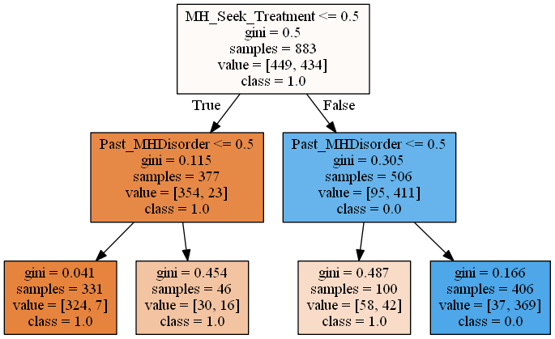

```python
# This code will visualize a decision tree dt, trained with the attributes in X and the class labels in Y
dt_feature_names = list(X.columns)
dt_target_names = [str(s) for s in Y.unique()]
tree.export_graphviz(dt, out_file='tree.dot',
    feature_names=dt_feature_names, class_names=dt_target_names,
    filled=True)
graph = pydotplus.graph_from_dot_file('tree.dot')
Image(graph.create_png())
```

Based on the Decision tree we see that majority of the people diagnosed with mental health illness undergoing treatment have had a past mental disorder

Analyzing futher based on 'CompanySize' for the people discussed above

```python
df_MH_PastDisorder=dfdummies[(dfdummies.Past_MHDisorder==1)& (dfdummies.MHDiagnosed==1)]
```

The graph shows that analysis of decision tree based on 'CompanySize'

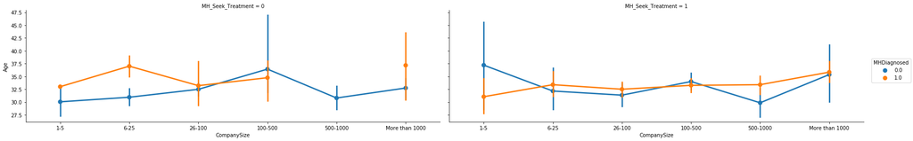

```python
sns.factorplot(x='CompanySize',y ='Age', hue='MHDiagnosed' ,col='MH_Seek_Treatment', data=df_tech ,\
               order=['1-5','6-25','26-100','100-500','500-1000','More than 1000'],kind ='point',aspect= 3 )
```

```python
dfgp_Mh=df_MH_PastDisorder.groupby('CompanySize')['Tech/Organization'].agg(['sum', 'count'])\
                    .rename(columns={'sum':'People in Tech','count':'Total_Number'})
dfgp_Mh=dfgp_Mh.reset_index()
dfgp_Mh.sort_values(by='People in Tech', ascending=False)
```

|  | CompanySize | People in Tech | Total_Number |
| --- | --- | --- | --- |
| 2 | 26-100 | 109.0 | 129 |
| 1 | 100-500 | 87.0 | 108 |
| 4 | 6-25 | 71.0 | 86 |
| 5 | More than 1000 | 69.0 | 127 |
| 3 | 500-1000 | 27.0 | 30 |
| 0 | 1-5 | 22.0 | 23 |

We see companies of size '26-100' have the most number of people in tech with past mental health disorder

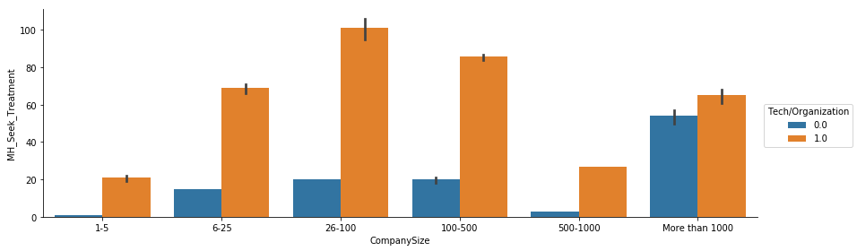

```python
sns.factorplot(x='CompanySize', hue='Tech/Organization', y='MH_Seek_Treatment',data= df_MH_PastDisorder,\
               order=['1-5','6-25','26-100','100-500','500-1000','More than 1000'],kind='bar', estimator=sum, aspect=3)
```

Next, we will analyze futher why company of this size '26-100' have more people with mental health illness.

```python
dftest= df_MH_PastDisorder[(df_MH_PastDisorder.CompanySize =='26-100')& (df_MH_PastDisorder.MH_Seek_Treatment ==1)]
```

Now, let's consider another factor -Does Mental health interfere with work when not treated effectively?

```python
dftest.groupby(by =['MH_InterfereswithworkNottreatedEffectively'])['Tech/Organization'].sum()
```

```
MH_InterfereswithworkNottreatedEffectively
0.0     2.0
0.5    28.0
1.0    71.0
Name: Tech/Organization, dtype: float64
```

It is intriguing to note that more that 50% of the people in the company who have been diagnosed with mental health issue already have had a mental health disorder and they are not treated effectively.

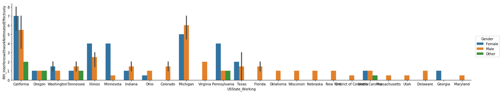

```python
sns.factorplot(x='USState_Working',y='MH_InterfereswithworkNottreatedEffectively' ,hue ='Gender',\
               estimator=sum,data= dftest,kind='bar',aspect=5)
```

Additionally, it is intresting that after California (The Silicon Valley), Michigan has people diagnosed with mental health problems when compared to other states.

Business Insight for Finding 1 - Business should root cause ineffective treatments within the company and set up health centers to aid employees.

### Finding 2

After analyzing the people with family history of mental health illness, it was surprising to find a strong correlation between two most popular mental health illnesses. Additionally, people with these illnesses felt they would be trated negatively by thier co-workers.

Summing up the diagnoses per survey/person

```python
dfdummies['Ydiagnosis_count']= dfdummies['ADD (w/o Hyperactivity)']+ dfdummies['Addictive Disorder']+\
    dfdummies['Anxiety Disorder (Generalized, Social, Phobia, etc)']+ dfdummies['Asperges']+ dfdummies[\
       'Attention Deficit Hyperactivity Disorder']+ dfdummies['Autism']+ dfdummies[\
       'Autism (Asperger\'s)']+ dfdummies['Autism Spectrum Disorder']+ dfdummies[\
       'Autism spectrum disorder']+ dfdummies['Burn out']+ dfdummies[\
       'Combination of physical impairment (strongly near-sighted) with a possibly mental one (MCD / "ADHD", though its actually a stimulus filtering impairment)']+ dfdummies[\
       'Depression']+ dfdummies['Dissociative Disorder']+ dfdummies[\
       'Eating Disorder (Anorexia, Bulimia, etc)']+ dfdummies['Gender Dysphoria']+ dfdummies[\
       'I haven\'t been formally diagnosed, so I felt uncomfortable answering, but Social Anxiety and Depression.']+ dfdummies[\
       'Intimate Disorder']+ dfdummies[\
       'Mood Disorder (Depression, Bipolar Disorder, etc)']+ dfdummies[\
       'Obsessive-Compulsive Disorder']+ dfdummies['PDD-NOS']+ dfdummies['PTSD (undiagnosed)']+ dfdummies[\
       'Personality Disorder (Borderline, Antisocial, Paranoid, etc)']+ dfdummies[\
       'Pervasive Developmental Disorder (Not Otherwise Specified)']+ dfdummies[\
       'Post-traumatic Stress Disorder']+ dfdummies[\
       'Psychotic Disorder (Schizophrenia, Schizoaffective, etc)']+ dfdummies[\
       'Schizotypal Personality Disorder']+ dfdummies['Seasonal Affective Disorder']+ dfdummies[\
       'Sexual addiction']+ dfdummies['Sleeping Disorder']+ dfdummies['Stress Response Syndromes']+ dfdummies[\
       'Substance Use Disorder']+ dfdummies['Transgender']+ dfdummies['Traumatic Brain Injury']
```

Next we will consider people with family history of mental health illness and who have had a past mental heath disorder.

```python
df_MHFamily =dfdummies[(dfdummies.MIFamily ==1 )& (dfdummies.Past_MHDisorder ==1)]
```

After exploring the data we found 'Mood Disorder (Depression, Bipolar Disorder, etc)' is the most frequent mental health illness

```python
dfdummies['Mood Disorder (Depression, Bipolar Disorder, etc)'].sum()
```

```
412
```

```python
df_MHFamily.groupby('Ydiagnosis_count')['Mood Disorder (Depression, Bipolar Disorder, etc)'].sum()
```

```
Ydiagnosis_count
0      0
1     64
2    113
3     60
4     23
5      7
6      5
7      3
8      2
9      1
Name: Mood Disorder (Depression, Bipolar Disorder, etc), dtype: int64
```

From the above data,It can be seen that many people have 2 mental health issues.Next, lets analyze graphically if 'Anxiety Disorder (Generalized, Social, Phobia, etc)' is correlated

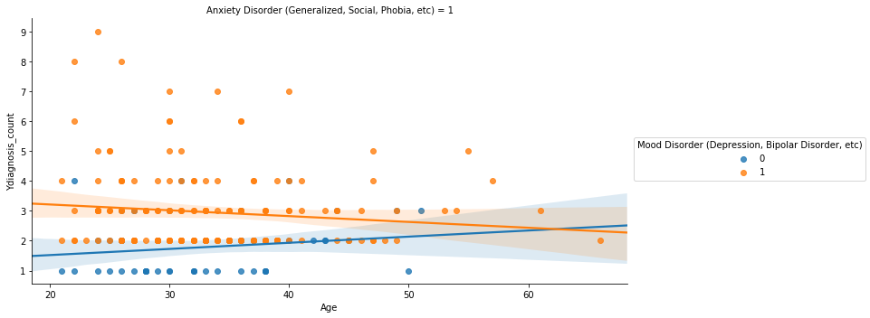

```python
sns.lmplot(hue='Mood Disorder (Depression, Bipolar Disorder, etc)',x ='Age' ,y='Ydiagnosis_count',\
          col='Anxiety Disorder (Generalized, Social, Phobia, etc)', data=df_MHFamily[(df_MHFamily.Age <70)& (df_MHFamily['Anxiety Disorder (Generalized, Social, Phobia, etc)']==1)],\
           aspect =2)
```

From the above graph, we observe that many people who have 2 or more diagnoses have 'Anxiety Disorder' and'Mood Disorder'

```python
dfMoodAnxiety=df_MHFamily[(df_MHFamily['Ydiagnosis_count'] >=2)]
```

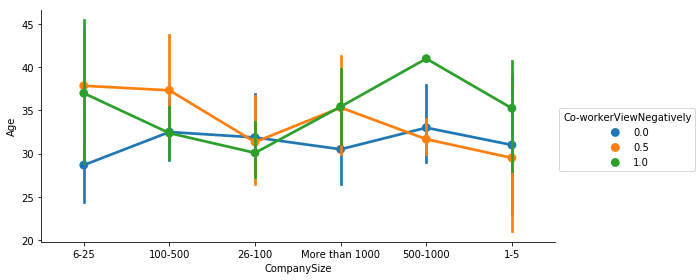

```python
sns.factorplot(x='CompanySize', y= 'Age',hue='Co-workerViewNegatively', data=dfMoodAnxiety[dfMoodAnxiety.MHCoverageExEmp !=.5], aspect=2)
```

The decision tree below will validate the above analysis

```python
dt = tree.DecisionTreeClassifier(max_depth=3)
X =dfdummies[(dfdummies ==1) |(dfdummies ==0)].drop(['PH_in_PEInterviewDesc','Mi_in_InterviewDesc','Gender',\
                                            'Country_Living','USState_Living',\
                                            'Country_Working','USState_Working','WorkPosition','MIFamily', 'Ydiagnosis',\
                                            'MHDiagnosedDesc'], axis =1)
Y =dfdummies[(dfdummies ==1) |(dfdummies ==0)]['MIFamily']
X.fillna(0, inplace=True)
Y.fillna(0, inplace=True)
dt.fit(X,Y)
```

```
DecisionTreeClassifier(class_weight=None, criterion='gini', max_depth=3,
            max_features=None, max_leaf_nodes=None,
            min_impurity_decrease=0.0, min_impurity_split=None,
            min_samples_leaf=1, min_samples_split=2,
            min_weight_fraction_leaf=0.0, presort=False, random_state=None,
            splitter='best')
```

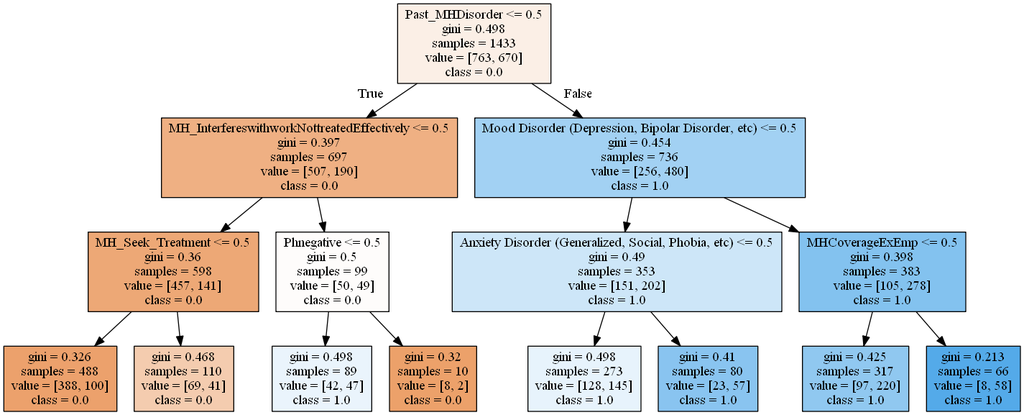

```python
# This code will visualize a decision tree dt, trained with the attributes in X and the class labels in Y
dt_feature_names = list(X.columns)
dt_target_names = [str(s) for s in Y.unique()]
tree.export_graphviz(dt, out_file='tree.dot',
    feature_names=dt_feature_names, class_names=dt_target_names,
    filled=True)
graph = pydotplus.graph_from_dot_file('tree.dot')
Image(graph.create_png())
```

Business Insight for Finding 2 : Business should recognize these popular mental health disorders and checking for the top two correlated diagnosis as preliminary testing

## Finding 3

Exploratory data analysis

```python
df.Gender.unique()
```

```
array(['Male', 'Female', 'Other'], dtype=object)
```

```python
df.Gender.count()
```

```
1433
```

```python
df.Gender.value_counts()
```

```
Male      893
Female    345
Other     195
Name: Gender, dtype: int64
```

Potting the data based on gender

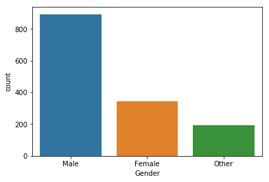

```python
sns.countplot(x='Gender',data=df)
```

Removing the outliers

```python
df_Age_group=df[(df.Age>20)& (df.Age<70)]
```

Since there's are lot of different ages in our data, we want to categorize them into different age groups

```python
df_Age_group['discretized_age']=pd.cut(df_Age_group.Age, bins=[20,30,40,50,60,70])
```

Considering only Males and Females

```python
dfMale_Female =df_Age_group[df_Age_group.Gender!='Other']
```

Note-Based on the data California is be considered as an outlier because its obvious and expected that people in California will have more number of people with mental health disorder.Hence California is excluded from this analysis

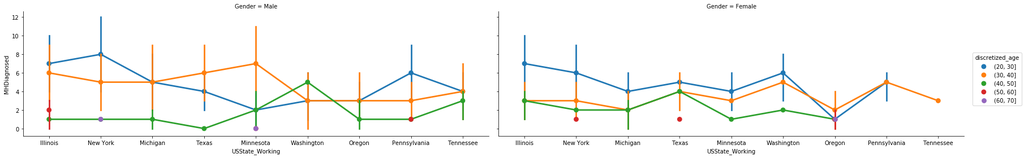

```python
sns.factorplot(hue='discretized_age',x='USState_Working',y='MHDiagnosed',col='Gender',estimator=sum,\
               data=dfMale_Female,kind= 'point',order=df_Age_group['USState_Working'].value_counts().iloc[1:10].index, aspect=3)
```

```python
dfFemale=dfMale_Female[(dfMale_Female.Gender=='Female')& (dfMale_Female['Tech/Organization'])==1]
```

```python
dfFemale_dummies= dfFemale.join(df2.WorkPosition.str.get_dummies(sep='|'), how='outer' )
dfFemale_dummies['NumberofWorkpositions']= dfFemale_dummies['Back-end Developer']+dfFemale_dummies['Designer']+dfFemale_dummies['DevOps/SysAdmin']+ dfFemale_dummies['Dev Evangelist/Advocate']+dfFemale_dummies['DevOps/SysAdmin']+ dfFemale_dummies['Executive Leadership']+ dfFemale_dummies['Front-end Developer'] +dfFemale_dummies['HR']+\
       dfFemale_dummies['One-person shop'] +dfFemale_dummies['Other'] +dfFemale_dummies['Sales'] +dfFemale_dummies['Supervisor/Team Lead'] +dfFemale_dummies['Support']
```

```python
dfFemale_dummies[dfFemale_dummies.discretized_age.isin([20, 30])].groupby(by=['USState_Working'] )['NumberofWorkpositions'].sum().nlargest()[-4:-1]
```

```
USState_Working
Illinois     15
Minnesota    11
Michigan     10
Name: NumberofWorkpositions, dtype: int64
```

Now to explore the sample of people claiming to have a mental disorder in tech based for Male

```python
dfMale=dfMale_Female[(dfMale_Female.Gender=='Male')& (dfMale_Female['Tech/Organization'])]
```

```python
dfMale_dummies= dfMale.join(df2.WorkPosition.str.get_dummies(sep='|'), how='outer' )
dfMale_dummies['NumberofWorkpositions']=dfMale_dummies['Back-end Developer']+dfMale_dummies['Designer']+ dfMale_dummies['Dev Evangelist/Advocate']+dfMale_dummies['DevOps/SysAdmin']+ dfMale_dummies['Executive Leadership']+ dfMale_dummies['Front-end Developer'] +dfMale_dummies['HR']+\
       dfMale_dummies['One-person shop'] +dfMale_dummies['Other'] +dfMale_dummies['Sales'] +dfMale_dummies['Supervisor/Team Lead'] +dfMale_dummies['Support']
```

```python
dfMale_dummies[dfMale_dummies.discretized_age.isin([20, 30])].groupby(by=['USState_Working'] )['NumberofWorkpositions'].sum().nlargest()[-4:-1]
```

```
USState_Working
Ohio        16
Illinois    15
Michigan    14
Name: NumberofWorkpositions, dtype: int64
```

Business Insight for Finding 3 :It is crutial for companies to ensure that their employee stay healthy mentally especially withing the age group of 20-30 as thier relative in-experience coupled with work pressure.Companies should provide more awareness of MH coverage and resources to their younger employees to improve their performance within the company